# Risk Factor Analysis

## Outcome Variable

**Outcome Variable:** whz

## Predictor Variables

**Intervention Variable:** safeh20

**Adjustment Set:**

- arm
- sex
- W_mage
- meducyrs
- feducyrs
- hhwealth_quart
- hfoodsec
- W_mhtcm
- W_mwtkg
- W_mbmi
- W_nrooms
- W_nchldlt5
- W_parity
- impfloor
- impsan
- delta_W_mage
- delta_meducyrs
- delta_feducyrs
- delta_hhwealth_quart
- delta_hfoodsec
- delta_W_mhtcm
- delta_W_mwtkg
- delta_W_mbmi
- delta_W_nrooms
- delta_W_nchldlt5
- delta_W_parity
- delta_impfloor
- delta_impsan

## Stratifying Variables

The analysis was stratified on these variable(s):

- agecat
- studyid
- country

## Data Summary

| agecat | studyid | country | safeh20 | n_cell | n | outcome_variable |
| --- | --- | --- | --- | --- | --- | --- |
| Birth | JiVitA-3 | BANGLADESH | 1 | 17963 | 17992 | whz |
| Birth | JiVitA-3 | BANGLADESH | 0 | 29 | 17992 | whz |
| Birth | JiVitA-4 | BANGLADESH | 1 | 2394 | 2394 | whz |
| Birth | JiVitA-4 | BANGLADESH | 0 | 0 | 2394 | whz |
| Birth | MAL-ED | BANGLADESH | 1 | 0 | 201 | whz |
| Birth | MAL-ED | BANGLADESH | 0 | 201 | 201 | whz |
| Birth | MAL-ED | BRAZIL | 1 | 0 | 38 | whz |
| Birth | MAL-ED | BRAZIL | 0 | 38 | 38 | whz |
| Birth | MAL-ED | INDIA | 1 | 0 | 39 | whz |
| Birth | MAL-ED | INDIA | 0 | 39 | 39 | whz |
| Birth | MAL-ED | NEPAL | 1 | 1 | 25 | whz |
| Birth | MAL-ED | NEPAL | 0 | 24 | 25 | whz |
| Birth | MAL-ED | PERU | 1 | 9 | 202 | whz |
| Birth | MAL-ED | PERU | 0 | 193 | 202 | whz |
| Birth | MAL-ED | SOUTH AFRICA | 1 | 13 | 95 | whz |
| Birth | MAL-ED | SOUTH AFRICA | 0 | 82 | 95 | whz |
| Birth | MAL-ED | TANZANIA, UNITED REPUBLIC OF | 1 | 74 | 111 | whz |
| Birth | MAL-ED | TANZANIA, UNITED REPUBLIC OF | 0 | 37 | 111 | whz |
| Birth | NIH-Birth | BANGLADESH | 1 | 573 | 575 | whz |
| Birth | NIH-Birth | BANGLADESH | 0 | 2 | 575 | whz |
| Birth | NIH-Crypto | BANGLADESH | 1 | 707 | 707 | whz |
| Birth | NIH-Crypto | BANGLADESH | 0 | 0 | 707 | whz |
| Birth | PROVIDE | BANGLADESH | 1 | 45 | 45 | whz |
| Birth | PROVIDE | BANGLADESH | 0 | 0 | 45 | whz |
| 6 months | CONTENT | PERU | 1 | 54 | 57 | whz |
| 6 months | CONTENT | PERU | 0 | 3 | 57 | whz |
| 6 months | JiVitA-3 | BANGLADESH | 1 | 16756 | 16776 | whz |
| 6 months | JiVitA-3 | BANGLADESH | 0 | 20 | 16776 | whz |
| 6 months | JiVitA-4 | BANGLADESH | 1 | 4826 | 4827 | whz |
| 6 months | JiVitA-4 | BANGLADESH | 0 | 1 | 4827 | whz |

[output cut: 52 more lines]

The following strata were considered:

- agecat: 24 months, studyid: CONTENT, country: PERU
- agecat: 24 months, studyid: JiVitA-3, country: BANGLADESH
- agecat: 24 months, studyid: JiVitA-4, country: BANGLADESH
- agecat: 24 months, studyid: LCNI-5, country: MALAWI
- agecat: 24 months, studyid: MAL-ED, country: BANGLADESH
- agecat: 24 months, studyid: MAL-ED, country: BRAZIL
- agecat: 24 months, studyid: MAL-ED, country: INDIA
- agecat: 24 months, studyid: MAL-ED, country: NEPAL
- agecat: 24 months, studyid: MAL-ED, country: PERU
- agecat: 24 months, studyid: MAL-ED, country: SOUTH AFRICA
- agecat: 24 months, studyid: MAL-ED, country: TANZANIA, UNITED REPUBLIC OF
- agecat: 24 months, studyid: NIH-Birth, country: BANGLADESH
- agecat: 24 months, studyid: NIH-Crypto, country: BANGLADESH
- agecat: 24 months, studyid: PROVIDE, country: BANGLADESH
- agecat: 6 months, studyid: CONTENT, country: PERU
- agecat: 6 months, studyid: JiVitA-3, country: BANGLADESH
- agecat: 6 months, studyid: JiVitA-4, country: BANGLADESH
- agecat: 6 months, studyid: LCNI-5, country: MALAWI
- agecat: 6 months, studyid: MAL-ED, country: BANGLADESH
- agecat: 6 months, studyid: MAL-ED, country: BRAZIL
- agecat: 6 months, studyid: MAL-ED, country: INDIA
- agecat: 6 months, studyid: MAL-ED, country: NEPAL
- agecat: 6 months, studyid: MAL-ED, country: PERU
- agecat: 6 months, studyid: MAL-ED, country: SOUTH AFRICA
- agecat: 6 months, studyid: MAL-ED, country: TANZANIA, UNITED REPUBLIC OF
- agecat: 6 months, studyid: NIH-Birth, country: BANGLADESH
- agecat: 6 months, studyid: NIH-Crypto, country: BANGLADESH
- agecat: 6 months, studyid: PROVIDE, country: BANGLADESH
- agecat: 6 months, studyid: SAS-FoodSuppl, country: INDIA
- agecat: Birth, studyid: JiVitA-3, country: BANGLADESH
- agecat: Birth, studyid: JiVitA-4, country: BANGLADESH
- agecat: Birth, studyid: MAL-ED, country: BANGLADESH
- agecat: Birth, studyid: MAL-ED, country: BRAZIL
- agecat: Birth, studyid: MAL-ED, country: INDIA
- agecat: Birth, studyid: MAL-ED, country: NEPAL
- agecat: Birth, studyid: MAL-ED, country: PERU
- agecat: Birth, studyid: MAL-ED, country: SOUTH AFRICA
- agecat: Birth, studyid: MAL-ED, country: TANZANIA, UNITED REPUBLIC OF
- agecat: Birth, studyid: NIH-Birth, country: BANGLADESH
- agecat: Birth, studyid: NIH-Crypto, country: BANGLADESH
- agecat: Birth, studyid: PROVIDE, country: BANGLADESH

### Dropped Strata

Some strata were dropped due to rare outcomes:

- agecat: Birth, studyid: JiVitA-4, country: BANGLADESH
- agecat: Birth, studyid: MAL-ED, country: BANGLADESH
- agecat: Birth, studyid: MAL-ED, country: BRAZIL
- agecat: Birth, studyid: MAL-ED, country: INDIA
- agecat: Birth, studyid: MAL-ED, country: NEPAL
- agecat: Birth, studyid: NIH-Birth, country: BANGLADESH
- agecat: Birth, studyid: NIH-Crypto, country: BANGLADESH
- agecat: Birth, studyid: PROVIDE, country: BANGLADESH
- agecat: 6 months, studyid: CONTENT, country: PERU
- agecat: 6 months, studyid: JiVitA-4, country: BANGLADESH
- agecat: 6 months, studyid: MAL-ED, country: BANGLADESH
- agecat: 6 months, studyid: MAL-ED, country: BRAZIL
- agecat: 6 months, studyid: MAL-ED, country: INDIA
- agecat: 6 months, studyid: MAL-ED, country: NEPAL
- agecat: 6 months, studyid: NIH-Birth, country: BANGLADESH
- agecat: 6 months, studyid: NIH-Crypto, country: BANGLADESH
- agecat: 6 months, studyid: PROVIDE, country: BANGLADESH
- agecat: 6 months, studyid: SAS-FoodSuppl, country: INDIA
- agecat: 24 months, studyid: CONTENT, country: PERU
- agecat: 24 months, studyid: JiVitA-4, country: BANGLADESH
- agecat: 24 months, studyid: MAL-ED, country: BANGLADESH
- agecat: 24 months, studyid: MAL-ED, country: BRAZIL
- agecat: 24 months, studyid: MAL-ED, country: INDIA
- agecat: 24 months, studyid: MAL-ED, country: NEPAL
- agecat: 24 months, studyid: NIH-Birth, country: BANGLADESH
- agecat: 24 months, studyid: NIH-Crypto, country: BANGLADESH
- agecat: 24 months, studyid: PROVIDE, country: BANGLADESH

## Methods Detail

We’re interested in the causal parameters $E[Y_a]$ for all values of $a \in \mathcal{A}$. These parameters represent the mean outcome if, possibly contrary to fact, we intervened to set all units to have $A=a$. Under the randomization and positivity assumptions, these are identified by the statistical parameters $\psi_a=E_W[E_{Y|A,W}(Y|A=a,W)]$. In addition, we’re interested in the mean of $Y$, $E[Y]$ under no intervention (the observed mean). We will estimate these parameters by using SuperLearner to fit the relevant likelihood factors – $E_{Y|A,W}(Y|A=a,W)$ and $p(A=a|W)$, and then updating our likelihood fit using a joint TMLE.

For unadjusted analyses ($W=\{\}$), initial likelihoods were estimated using Lrnr_glm to estimate the simple $E(Y|A)$ and Lrnr_mean to estimate $p(A)$. For adjusted analyses, a small library containing Lrnr_glmnet, Lrnr_xgboost, and Lrnr_mean was used.

Having estimated these parameters, we will then use the delta method to estimate relative risks and attributable risks relative to a prespecified baseline level of $A$.

# Results Detail

## Results Plots

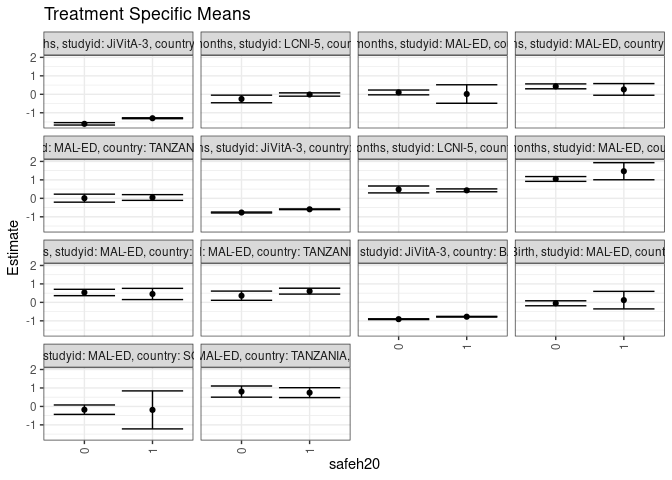

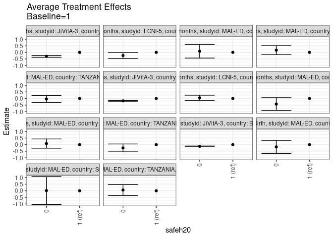

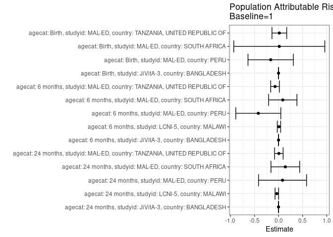

## Results Table

### Parameter: TSM

| agecat | studyid | country | intervention_level | baseline_level | estimate | ci_lower | ci_upper |
| --- | --- | --- | --- | --- | --- | --- | --- |
| Birth | JiVitA-3 | BANGLADESH | 1 | NA | -0.7775540 | -0.7970320 | -0.7580761 |
| Birth | JiVitA-3 | BANGLADESH | 0 | NA | -0.9092330 | -0.9301932 | -0.8882727 |
| Birth | MAL-ED | PERU | 1 | NA | 0.1222222 | -0.3522777 | 0.5967221 |
| Birth | MAL-ED | PERU | 0 | NA | -0.0486528 | -0.1831806 | 0.0858749 |
| Birth | MAL-ED | SOUTH AFRICA | 1 | NA | -0.1882814 | -1.2173184 | 0.8407555 |
| Birth | MAL-ED | SOUTH AFRICA | 0 | NA | -0.1776190 | -0.4326485 | 0.0774105 |
| Birth | MAL-ED | TANZANIA, UNITED REPUBLIC OF | 1 | NA | 0.7456230 | 0.4775629 | 1.0136831 |
| Birth | MAL-ED | TANZANIA, UNITED REPUBLIC OF | 0 | NA | 0.8036808 | 0.5014608 | 1.1059009 |
| 6 months | JiVitA-3 | BANGLADESH | 1 | NA | -0.5930104 | -0.6129865 | -0.5730343 |
| 6 months | JiVitA-3 | BANGLADESH | 0 | NA | -0.7687144 | -0.7937722 | -0.7436566 |
| 6 months | LCNI-5 | MALAWI | 1 | NA | 0.4331770 | 0.3559255 | 0.5104286 |
| 6 months | LCNI-5 | MALAWI | 0 | NA | 0.4811478 | 0.2939648 | 0.6683308 |
| 6 months | MAL-ED | PERU | 1 | NA | 1.4692570 | 1.0059400 | 1.9325739 |
| 6 months | MAL-ED | PERU | 0 | NA | 1.0487657 | 0.9186322 | 1.1788992 |
| 6 months | MAL-ED | SOUTH AFRICA | 1 | NA | 0.4552518 | 0.1520660 | 0.7584376 |
| 6 months | MAL-ED | SOUTH AFRICA | 0 | NA | 0.5358275 | 0.3636309 | 0.7080240 |
| 6 months | MAL-ED | TANZANIA, UNITED REPUBLIC OF | 1 | NA | 0.6082598 | 0.4483004 | 0.7682193 |
| 6 months | MAL-ED | TANZANIA, UNITED REPUBLIC OF | 0 | NA | 0.3613260 | 0.1119203 | 0.6107318 |
| 24 months | JiVitA-3 | BANGLADESH | 1 | NA | -1.2970059 | -1.3208086 | -1.2732032 |
| 24 months | JiVitA-3 | BANGLADESH | 0 | NA | -1.6003100 | -1.6647621 | -1.5358580 |
| 24 months | LCNI-5 | MALAWI | 1 | NA | -0.0124028 | -0.1021488 | 0.0773432 |
| 24 months | LCNI-5 | MALAWI | 0 | NA | -0.2522750 | -0.4583682 | -0.0461819 |
| 24 months | MAL-ED | PERU | 1 | NA | 0.0150000 | -0.4862499 | 0.5162499 |
| 24 months | MAL-ED | PERU | 0 | NA | 0.1005332 | -0.0288801 | 0.2299464 |
| 24 months | MAL-ED | SOUTH AFRICA | 1 | NA | 0.2647238 | -0.0496892 | 0.5791368 |
| 24 months | MAL-ED | SOUTH AFRICA | 0 | NA | 0.4300361 | 0.2976872 | 0.5623850 |
| 24 months | MAL-ED | TANZANIA, UNITED REPUBLIC OF | 1 | NA | 0.0456176 | -0.1098621 | 0.2010972 |
| 24 months | MAL-ED | TANZANIA, UNITED REPUBLIC OF | 0 | NA | 0.0093690 | -0.2062841 | 0.2250222 |

### Parameter: E(Y)

| agecat | studyid | country | intervention_level | baseline_level | estimate | ci_lower | ci_upper |
| --- | --- | --- | --- | --- | --- | --- | --- |
| Birth | JiVitA-3 | BANGLADESH | NA | NA | -0.7777807 | -0.7967797 | -0.7587816 |
| Birth | MAL-ED | PERU | NA | NA | -0.0410396 | -0.1713918 | 0.0893125 |
| Birth | MAL-ED | SOUTH AFRICA | NA | NA | -0.1729474 | -0.4186222 | 0.0727275 |
| Birth | MAL-ED | TANZANIA, UNITED REPUBLIC OF | NA | NA | 0.7618919 | 0.5640188 | 0.9597650 |
| 6 months | JiVitA-3 | BANGLADESH | NA | NA | -0.5932502 | -0.6127743 | -0.5737261 |
| 6 months | LCNI-5 | MALAWI | NA | NA | 0.4417647 | 0.3702742 | 0.5132552 |
| 6 months | MAL-ED | PERU | NA | NA | 1.0487066 | 0.9226025 | 1.1748107 |
| 6 months | MAL-ED | SOUTH AFRICA | NA | NA | 0.5430175 | 0.3887455 | 0.6972895 |
| 6 months | MAL-ED | TANZANIA, UNITED REPUBLIC OF | NA | NA | 0.5357995 | 0.4039850 | 0.6676139 |
| 24 months | JiVitA-3 | BANGLADESH | NA | NA | -1.2973086 | -1.3206115 | -1.2740057 |
| 24 months | LCNI-5 | MALAWI | NA | NA | -0.0477867 | -0.1301103 | 0.0345368 |
| 24 months | MAL-ED | PERU | NA | NA | 0.0974309 | -0.0286270 | 0.2234888 |
| 24 months | MAL-ED | SOUTH AFRICA | NA | NA | 0.4054395 | 0.2840471 | 0.5268320 |
| 24 months | MAL-ED | TANZANIA, UNITED REPUBLIC OF | NA | NA | 0.0518153 | -0.0737716 | 0.1774023 |

### Parameter: ATE

| agecat | studyid | country | intervention_level | baseline_level | estimate | ci_lower | ci_upper |
| --- | --- | --- | --- | --- | --- | --- | --- |
| Birth | JiVitA-3 | BANGLADESH | 1 | 1 | 0.0000000 | 0.0000000 | 0.0000000 |
| Birth | JiVitA-3 | BANGLADESH | 0 | 1 | -0.1316790 | -0.1604986 | -0.1028593 |
| Birth | MAL-ED | PERU | 1 | 1 | 0.0000000 | 0.0000000 | 0.0000000 |
| Birth | MAL-ED | PERU | 0 | 1 | -0.1708751 | -0.6640768 | 0.3223266 |
| Birth | MAL-ED | SOUTH AFRICA | 1 | 1 | 0.0000000 | 0.0000000 | 0.0000000 |
| Birth | MAL-ED | SOUTH AFRICA | 0 | 1 | 0.0106625 | -1.0501856 | 1.0715105 |
| Birth | MAL-ED | TANZANIA, UNITED REPUBLIC OF | 1 | 1 | 0.0000000 | 0.0000000 | 0.0000000 |
| Birth | MAL-ED | TANZANIA, UNITED REPUBLIC OF | 0 | 1 | 0.0580578 | -0.3546538 | 0.4707695 |
| 6 months | JiVitA-3 | BANGLADESH | 1 | 1 | 0.0000000 | 0.0000000 | 0.0000000 |
| 6 months | JiVitA-3 | BANGLADESH | 0 | 1 | -0.1757040 | -0.2068854 | -0.1445226 |
| 6 months | LCNI-5 | MALAWI | 1 | 1 | 0.0000000 | 0.0000000 | 0.0000000 |
| 6 months | LCNI-5 | MALAWI | 0 | 1 | 0.0479707 | -0.1546573 | 0.2505988 |
| 6 months | MAL-ED | PERU | 1 | 1 | 0.0000000 | 0.0000000 | 0.0000000 |
| 6 months | MAL-ED | PERU | 0 | 1 | -0.4204913 | -0.9037816 | 0.0627991 |
| 6 months | MAL-ED | SOUTH AFRICA | 1 | 1 | 0.0000000 | 0.0000000 | 0.0000000 |
| 6 months | MAL-ED | SOUTH AFRICA | 0 | 1 | 0.0805757 | -0.2675773 | 0.4287286 |
| 6 months | MAL-ED | TANZANIA, UNITED REPUBLIC OF | 1 | 1 | 0.0000000 | 0.0000000 | 0.0000000 |
| 6 months | MAL-ED | TANZANIA, UNITED REPUBLIC OF | 0 | 1 | -0.2469338 | -0.5440917 | 0.0502241 |
| 24 months | JiVitA-3 | BANGLADESH | 1 | 1 | 0.0000000 | 0.0000000 | 0.0000000 |
| 24 months | JiVitA-3 | BANGLADESH | 0 | 1 | -0.3033041 | -0.3718159 | -0.2347923 |
| 24 months | LCNI-5 | MALAWI | 1 | 1 | 0.0000000 | 0.0000000 | 0.0000000 |
| 24 months | LCNI-5 | MALAWI | 0 | 1 | -0.2398722 | -0.4640142 | -0.0157303 |
| 24 months | MAL-ED | PERU | 1 | 1 | 0.0000000 | 0.0000000 | 0.0000000 |
| 24 months | MAL-ED | PERU | 0 | 1 | 0.0855332 | -0.4321533 | 0.6032196 |
| 24 months | MAL-ED | SOUTH AFRICA | 1 | 1 | 0.0000000 | 0.0000000 | 0.0000000 |
| 24 months | MAL-ED | SOUTH AFRICA | 0 | 1 | 0.1653123 | -0.1770299 | 0.5076544 |
| 24 months | MAL-ED | TANZANIA, UNITED REPUBLIC OF | 1 | 1 | 0.0000000 | 0.0000000 | 0.0000000 |
| 24 months | MAL-ED | TANZANIA, UNITED REPUBLIC OF | 0 | 1 | -0.0362486 | -0.3030044 | 0.2305073 |

### Parameter: PAR

| agecat | studyid | country | intervention_level | baseline_level | estimate | ci_lower | ci_upper |
| --- | --- | --- | --- | --- | --- | --- | --- |
| Birth | JiVitA-3 | BANGLADESH | 1 | NA | -0.0002267 | -0.0009339 | 0.0004806 |
| Birth | MAL-ED | PERU | 1 | NA | -0.1632618 | -0.6345144 | 0.3079907 |
| Birth | MAL-ED | SOUTH AFRICA | 1 | NA | 0.0153341 | -0.9303303 | 0.9609984 |
| Birth | MAL-ED | TANZANIA, UNITED REPUBLIC OF | 1 | NA | 0.0162689 | -0.1369104 | 0.1694483 |
| 6 months | JiVitA-3 | BANGLADESH | 1 | NA | -0.0002398 | -0.0010224 | 0.0005429 |
| 6 months | LCNI-5 | MALAWI | 1 | NA | 0.0085877 | -0.0268779 | 0.0440532 |
| 6 months | MAL-ED | PERU | 1 | NA | -0.4205504 | -0.8879942 | 0.0468934 |
| 6 months | MAL-ED | SOUTH AFRICA | 1 | NA | 0.0877657 | -0.2067495 | 0.3822809 |
| 6 months | MAL-ED | TANZANIA, UNITED REPUBLIC OF | 1 | NA | -0.0724604 | -0.1630874 | 0.0181667 |
| 24 months | JiVitA-3 | BANGLADESH | 1 | NA | -0.0003026 | -0.0020768 | 0.0014715 |
| 24 months | LCNI-5 | MALAWI | 1 | NA | -0.0353839 | -0.0727215 | 0.0019537 |
| 24 months | MAL-ED | PERU | 1 | NA | 0.0824309 | -0.4164844 | 0.5813463 |
| 24 months | MAL-ED | SOUTH AFRICA | 1 | NA | 0.1407157 | -0.1576675 | 0.4390989 |
| 24 months | MAL-ED | TANZANIA, UNITED REPUBLIC OF | 1 | NA | 0.0061978 | -0.0827574 | 0.0951529 |